# iQ Winter School 2018 on Machine Learning Applied to Quantitative Analysis of Medical Images

## Hands-on Session 1 - Tutorial

## Part 2 - Convolutional Neural Networks (CNN)

### 1. Import libraries

First, we are going to import the libraries that will be used in this part of the tutorial.

```python
import numpy as np
import keras
from keras.models import Sequential
from keras.layers import Conv2D, MaxPooling2D, Activation, Dropout, Flatten, Dense
import sklearn.model_selection
from keras.preprocessing.image import ImageDataGenerator
from keras import backend as K
from pylab import *
import skimage.transform, skimage.filters

import warnings
warnings.filterwarnings("ignore")

def precision(y_true, y_pred):
    true_positives = K.sum(K.round(K.clip(y_true * y_pred, 0, 1)))
    predicted_positives = K.sum(K.round(K.clip(y_pred, 0, 1)))
    precision = true_positives / (predicted_positives + K.epsilon())
    return precision

def recall(y_true, y_pred):
    true_positives = K.sum(K.round(K.clip(y_true * y_pred, 0, 1)))
    possible_positives = K.sum(K.round(K.clip(y_true, 0, 1)))
    recall = true_positives / (possible_positives + K.epsilon())
    return recall

def f1(y_true, y_pred):
    rec = recall(y_true, y_pred)
    prec = precision(y_true, y_pred)
    return 2*((prec*rec)/(prec+rec))

print("Hoorray, no import errors!")
```

```
Hoorray, no import errors!
```

### 2. Load data from the OASIS database.

This is the same dataset we have used in the first part of this tutorial.

```python
subjects = np.load(r'data/subjects_masked_bfc_resc.npy')
labels = np.load(r'data/labels.npy')
nb_labels_class = np.bincount(labels)
num_classes = nb_labels_class.size
N_subjects = subjects.shape[0]
N_features = subjects.shape[1]
print("%d healthy, %d AD" % ((labels==0).sum(), (labels==1).sum()))
print("number of samples: %d, number of features: %d" % (N_subjects, N_features))
```

```
66 healthy, 71 AD
number of samples: 137, number of features: 30976
```

Due to memory restrictions, we will need to downsample the 2D slices four times. To avoid aliasing artifacts, we will smooth the image prior to resampling.

#### Downsample the images

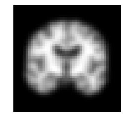

```python
# downsample the images
subjects = subjects.reshape((137,176,176))
new_shape = (44,44,1)
subjects_ds = []
for subj in range(subjects.shape[0]):
    img = subjects[subj,:,:].reshape((176,176))
    img = skimage.filters.gaussian(img, sigma=4)
    subjects_ds.append(skimage.transform.resize(img, new_shape))
subjects_ds = np.array(subjects_ds)

figure()
imshow(subjects_ds[0,:,:,0], cmap='gray')
axis('off')
show()
```

Now, we will train a small CNN (the LeNet-5 with a few modifications) on a portion of the dataset and test it on the remaining samples.

### 3. Train and test a small CNN

We will first split and prepare the data for training and testing.

```python
# split into training and testing
x_train, x_test, y_train, y_test = sklearn.model_selection.train_test_split(subjects_ds, labels, test_size=0.2, stratify = labels)
y_train = keras.utils.to_categorical(y_train, num_classes)
y_test = keras.utils.to_categorical(y_test, num_classes)
```

Now we will create a CNN and visualize it schematically. The architecture is similar to that of the LeNet-5 (Lecun '98).

```python
# some hyperparameters
batch_size = 10 # number of training examples seen at each iteration of the optimizer
epochs = 300 # number of iterations over the whole training set

receptive_field_size = 5
activation = 'relu' # Rectified Linear Unit
pool_size = (2,2)
nb_filters_conv1 = 12
nb_filters_conv2 = 24
nb_neurons_dense1 = 180 # 180 neurons in the first fully connected layer
nb_neurons_dense2 = 100
p_dropout = 0.5 # dropout of 50% of the neurons

model = Sequential()
model.add(Conv2D(nb_filters_conv1, receptive_field_size, receptive_field_size, \
                 activation = activation, input_shape=new_shape))
model.add(MaxPooling2D(pool_size = pool_size))
model.add(Dropout(p_dropout))
model.add(Conv2D(nb_filters_conv2, receptive_field_size, receptive_field_size, \
                 activation = activation))
model.add(MaxPooling2D(pool_size = pool_size))
model.add(Dropout(p_dropout))
model.add(Flatten())
model.add(Dense(nb_neurons_dense1, activation = activation))
model.add(Dropout(p_dropout))
model.add(Dense(nb_neurons_dense2, activation = activation))
model.add(Dropout(p_dropout))
model.add(Dense(num_classes, activation = 'softmax'))

model.compile(loss='categorical_crossentropy', optimizer='adamax', metrics=[f1])

print(model.summary())
```

```
_________________________________________________________________
Layer (type)                 Output Shape              Param #
=================================================================
conv2d_1 (Conv2D)            (None, 40, 40, 12)        312
_________________________________________________________________
max_pooling2d_1 (MaxPooling2 (None, 20, 20, 12)        0
_________________________________________________________________
dropout_1 (Dropout)          (None, 20, 20, 12)        0
_________________________________________________________________
conv2d_2 (Conv2D)            (None, 16, 16, 24)        7224
_________________________________________________________________
max_pooling2d_2 (MaxPooling2 (None, 8, 8, 24)          0
_________________________________________________________________
dropout_2 (Dropout)          (None, 8, 8, 24)          0
_________________________________________________________________
flatten_1 (Flatten)          (None, 1536)              0
_________________________________________________________________
dense_1 (Dense)              (None, 180)               276660
_________________________________________________________________
dropout_3 (Dropout)          (None, 180)               0
_________________________________________________________________
dense_2 (Dense)              (None, 100)               18100
_________________________________________________________________
dropout_4 (Dropout)          (None, 100)               0
_________________________________________________________________
dense_3 (Dense)              (None, 2)                 202
=================================================================
Total params: 302,498
Trainable params: 302,498
Non-trainable params: 0
_________________________________________________________________
None
```

```
Train on 109 samples, validate on 28 samples
```

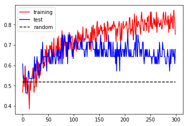

```python
history = model.fit(x_train, y_train, batch_size=batch_size, nb_epoch=epochs, \
                    verbose=1, \
                    validation_data=(x_test,y_test))

F1_random = nb_labels_class[1]/labels.size # random classification F1 score

figure()
plot(history.history['f1'], '-r', label='training')
plot(history.history['val_f1'], '-b', label='test')
plot(np.arange(epochs), np.ones(epochs)*F1_random, '--k', label = 'random')
legend()
show()
```

##### ----- What's the effect of dropout regularization in the model's performance? What happens when you don't use it at all? What network hyperparameters have the highest impact?

### 4. Data augmentation

Besides regularization (like dropout), another common strategy to circumvent overfitting is to increase the size of the training set by performing data augmentation.

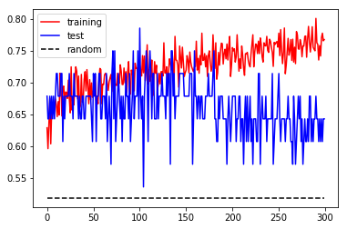

```python
# Performs data augmentation
datagen = ImageDataGenerator(
        featurewise_center=False,  # set input mean to 0 over the dataset
        samplewise_center=False,  # set each sample mean to 0
        featurewise_std_normalization=False,  # divide inputs by std of the dataset
        samplewise_std_normalization=False,  # divide each input by its std
        zca_whitening=False,  # apply ZCA whitening
        rotation_range=0,  # randomly rotate images in the range (degrees, 0 to 180)
        width_shift_range=0.1,  # randomly shift images horizontally (fraction of total width)
        height_shift_range=0.1,  # randomly shift images vertically (fraction of total height)
        horizontal_flip=True,  # randomly flip images
        vertical_flip=True)  # randomly flip images

datagen.fit(x_train)

history = model.fit_generator(datagen.flow(x_train, y_train, batch_size=batch_size),
                                epochs=epochs,
                                steps_per_epoch=40,
                                verbose=0,
                                validation_data=(x_test, y_test),
                                workers=4)

# Plots the learning curves
figure()
plot(history.history['f1'], '-r', label='training')
plot(history.history['val_f1'], '-b', label='test')
plot(np.arange(epochs), np.ones(epochs)*F1_random, '--k', label = 'random')
legend()
show()
```

##### ----- Do all of the augmentation techniques used above make sense in this classification problem? What other transformations could you apply to the images to increase the training set size? How does the network perform compared to not doing any augmentation?

### 5. Network visualization

Finally, you may want to inspect the weights at a given layer in the CNN. Here, we show the weight matrices from the very first convolutional layer.

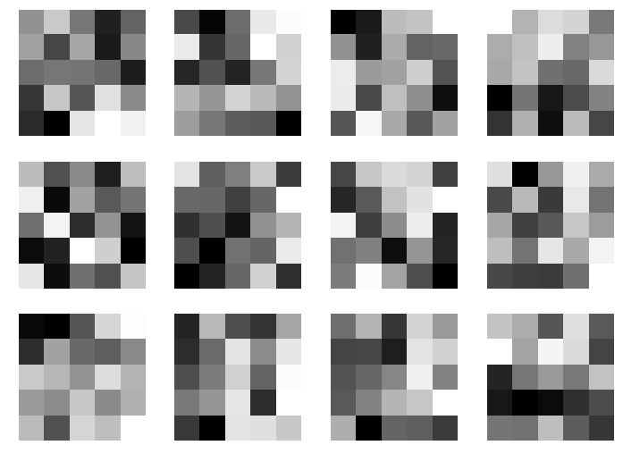

```python
conv_layer = model.layers[0] # selects the first convolutional layer
weights = conv_layer.get_weights() # gets the layer's weights
nb_filters = weights[1].size

n = ceil(np.sqrt(nb_filters))
figure(figsize=(12,12))
for i in range(nb_filters):
    w = weights[0][:,:,0,i]
    subplot(n,n,i+1)
    imshow(w, cmap='gray')
    axis('off')
show()
```

These weights matrices have probably not added much information about how the network is learning. Another more useful thing you could do is visualize the actual layer outputs:

```
Shape of the output of the first convolutional layer:  (40, 40, 12)
```

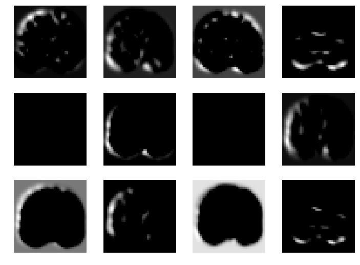

```python
get_layer_output = K.function([conv_layer.input, K.learning_phase()],
                                  [conv_layer.output])

# Takes the first test image
img = x_test[0,...][np.newaxis,...]

# output in test mode -->  K.learning_phase() must be 0
layer_output = get_layer_output([img, 0])[0]
print("Shape of the output of the first convolutional layer: ", layer_output[0].shape) # 12 filter maps (40x40) after the first convolutional layer

# Visualize the filter maps after the first Conv layer
figure(figsize=(12,12))
for i in range(nb_filters):
    filter_map = layer_output[0][:,:,i]
    subplot(n,n,i+1)
    imshow(filter_map, cmap='gray', interpolation = None)
    axis('off')
show()
```

##### ----- What can you tell from these results?